# act_report

## weRateDogs conclusion

in this report I am going to discuss some insights and visualizations I got while working on the wrangling of weRate dogs data this data is mainly about an account on Twitter that posts photos of dogs and a short description for them associated with a rate for them. Mainly I gathered the data from three sources and saved them in three dataframes i tried to apply the wrangling techniques in this project from the beginning like gathering the data from different resources , assessing the dataframes visually and programmatically then the last step is the cleaning step which is mainly the most important, tricky and the easiest step among them. the cleaning step is divided into quality and tidiness issues to be addressed. gathering the data in this project was from

- a url that hosts the data
- csv file introduced by udacity
- twitter api to save them in a json file

It is interesting to ask yourself what may be affecting the rate of the dogs and is the rate reflecting the retweet and favorite counts. also you may ask is the tweets always is the same source are they always from mobile or may be coming from web client also getting some insights through the history of the account would be joyable and enjoyful process.

Here I will begin by the insights that I got from the data the first insight that I was really curious about is, what is the maximum retweets we have ? the answer was interesting, the maximum retweets we got was **74352**, there is a tweet that went viral and got +74K retweets the second insight that I looked into what could be the number of the minimum retweets that a photo took ? the answer was a pretty shocking, just **one** retweet

I did the same for the favorite counts to know out of curiosity what are the maximum and the minimum values and I found the maximum favorited tweet got **150651** which means **+150k** for the tweet and the minimum favorties a tweet got was **49** only

I asked later did the minimum retweet counts means minimum favorites and the same question go for the maximum I found that in the case of the maximum that was *True* the maximum favorited tweet got the maximum retweet counts but that was **un true** for **minimum case** as the minimum retweet which was 1 retweet got **136 favorites**

## then I asked myself which source has the maximum numbr of tweets, I found that the maximum number of tweets was by an Iphone as it is clear in the below in the visualization

## First visualization

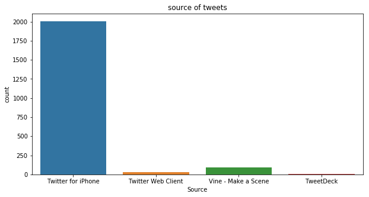

## another question that i was curiois about how people are likely to rate the dogs ? , are they tough and gie low rating or they are kindly giving them high rates that would be a more clearer if we plotted a distribution showing the ratings

## Second visualization

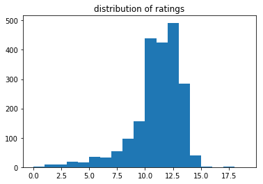

## it is clear that peopel tends to give a higher ratings more than 10 and our audience is kindly, this distribution appears to be left skewed so that ratings in lower number tends to decrease